# Appendix. C: Summary of R code used in statistical analyses and visualisation. R version 4.5.1.

Mako Shibata

# Preamble

### Packages

```r
library(tidyr) #formatting
library(dplyr) #manipulation
library(ggplot2) #visualisation
library(readr) #manipulation
library(ggpubr) #visualisation
library(knitr) #visualisation
library(stats) #power analysis
library(pander) #visualisation
library(broom) #visualisation
```

### Load Data

```r
# set working directory
setwd("/Users/Owner/Library/CloudStorage/OneDrive-UniversityofEdinburgh/#00_EM/Project_Soil Microclimate/EM_SoilMicroclimate")

# load raw data
soil <- read.csv("RAW_ALL_soil_microclimate.csv")

# combine tree species entry into one column
# remove unnecessary columns
soil <- soil %>%
  mutate(Tree.species = if_else(
    Tree.species == "other",
    Other..specify....Tree.species,
    Tree.species)) %>%
  select(-Other..specify....Tree.species,
         -Mixed.Other..specify....Ground.Cover.Types,
         -Ground.Cover.Types)

# create a long format data, gathered by Distance (0.5 and 7.0 m)
soil0.5 <- soil %>%
  select(Date = Date...Time,
         TreeID = Tree.Plot.ID..,
         Species = Tree.species,
         DBH_cm = DBH..cm.,
         Cardinal = Cardinal.Direction,
         Depth_cm = Soil.organic.layer.depth..cm.,
         Moisture_vv = Soil.moisture....V.V.,
         Distance = Distance.from.tree.trunk..m.,
         Notes = Notes...Comments,
         x = x,
         y = y
         )

soil7.0 <- soil %>%
  select(Date = Date...Time,
         TreeID = Tree.Plot.ID..,
         Species = Tree.species,
         DBH_cm = DBH..cm.,
         Cardinal = Cardinal.Direction,
         Depth_cm = Soil.organic.layer.depth..cm..1,
         Moisture_vv = Soil.moisture....V.V..1,
         Distance = Distance.from.tree.trunk..m..1,
         Notes = Notes...Comments,
         x = x,
         y = y
  )

soil_all <- bind_rows(soil0.5, soil7.0) %>%
  arrange(TreeID, Distance) %>%
  mutate(running_order = row_number()) %>%
  relocate(running_order, .before = TreeID) %>%
  select(-Notes)

# set distance as a factor
soil_all$Distance <- as.factor(soil_all$Distance)
# omit N/A rows
soil_all <- na.omit(soil_all)
```

### Clean data

The following procedure corrects the species mis-entry (English Oak to Silver Birch), adds a column of Genus and management types for group-specific analyses, and creates a new data frame with no Scots Pine data. Scots Pine is removed due to its sample size being 1.

```r
# replace oak with birch, set genus name in a new column.
soil_all <- soil_all %>%
  mutate(Species = recode(Species,
                          "English Oak (Quercus robur)" = "Silver Birch (Betula pendula)")) %>%
  mutate(Genus = case_when(
    Species == "Alder" ~ "Alnus",
    Species == "Silver Birch (Betula pendula)" ~ "Betula",
    Species == "Downy Birch (Betula pubescens)" ~ "Betula",
    Species == "Scots pine (Pinus sylvestris)" ~ "Pinus",
    Species == "Rowan (Sorbus aucuparia)" ~ "Sorbus"
  ))  %>%
  relocate(Genus, .before = Species)

# create a management type column using TreeID that falls within a specific management regime
soil_all<- soil_all %>%
  mutate(soil_all, Management = case_when(
    TreeID %in% c(1, 2, 3, 4, 5, 6, 7, 21, 22, 23, 24, 25) ~ "No mound",
    TRUE ~ "mound")) %>%
  relocate(Management, .after = Species)

# save cleaned data including pine
write.csv(soil_all, "soil_all.csv")

# remove pine
soil_all_nonpine <- soil_all %>%
  filter(Genus != "Pinus")

# save cleaned data excluding pine
write.csv(soil_all_nonpine, "soil_all_nonpine.csv")
```

# DBH (cm) and Age

The following codes calculated mean, standard deviation, max, and minimum of DBH (cm) for total species and all genus groups. DBH is converted to age by applying a growth factor of 2.5 cm/year (Mitchell, 1974).

```r
# read soil_all_pine as soil
soil <- soil_all_nonpine
# get average DBH (cm) +- std for the following groups: total, alder, birch, sorbus
DBH_mean <- c(mean(soil$DBH_cm),
              mean(soil$DBH_cm[soil$Genus == "Alnus"]),
              mean(soil$DBH_cm[soil$Genus == "Betula"]),
              mean(soil$DBH_cm[soil$Genus == "Sorbus"]))

DBH_sd <- c(sd(soil$DBH_cm), sd(soil$DBH_cm[soil$Genus == "Alnus"]),
            sd(soil$DBH_cm[soil$Genus == "Betula"]),
            sd(soil$DBH_cm[soil$Genus == "Sorbus"]))

DBH_max <- c(max(soil$DBH_cm),
             max(soil$DBH_cm[soil$Genus == "Alnus"]),
             max(soil$DBH_cm[soil$Genus == "Betula"]),
             max(soil$DBH_cm[soil$Genus == "Sorbus"]))

DBH_min <- c(min(soil$DBH_cm),
             min(soil$DBH_cm[soil$Genus == "Alnus"]),
             min(soil$DBH_cm[soil$Genus == "Betula"]),
             min(soil$DBH_cm[soil$Genus == "Sorbus"]))

Genus <- c("Total", "Alnus", "Betula", "Sorbus")

# create a data frame
DBH_Age <- data.frame(Genus, DBH_mean, DBH_sd, DBH_max, DBH_min)
names(DBH_Age) <- c("Genus", "meanDBH", "stdDBH", "maxDBH", "minDBH")

# converting this to girth
DBH_Age <- DBH_Age %>%
  mutate(girth_cm = meanDBH*3.14,
         sd_girth_cm = stdDBH*3.14,
         girth_max = DBH_max*3.14,
         girth_min = DBH_min*3.14)

# applying the growth rate = 2.5 cm to estimate age
DBH_Age<- DBH_Age %>%
  mutate(mean_age = girth_cm/2.5,
         age_sd = sd_girth_cm/2.5,
         maxage = girth_max/2.5,
         minage = girth_min/2.5)

write.csv(DBH_Age, "DBH_Age.csv")

# outputs
DBH_Age_outputs <- DBH_Age %>%
  select(Genus, mean_age, age_sd, maxage, minage)
kable(DBH_Age_outputs, digits = 1)
```

| Genus | mean_age | age_sd | maxage | minage |
| --- | --- | --- | --- | --- |
| Total | 10.3 | 6.8 | 32.7 | 4.0 |
| Alnus | 10.7 | 10.9 | 28.4 | 4.0 |
| Betula | 10.5 | 6.1 | 32.7 | 4.3 |
| Sorbus | 8.6 | 3.6 | 12.8 | 4.9 |

# Power Analyses

### Code

The following addresses the question; what is the sample size required to run one-way ANOVA?

```r
# One-Way ANOVA setting
# alpha = 0.05
# power = 0.80
# group = 2

power.anova.test(groups = 2, between.var = 1, within.var = 3, power = 0.8)
```

```
##
##      Balanced one-way analysis of variance power calculation
##
##          groups = 2
##               n = 24.54495
##     between.var = 1
##      within.var = 3
##       sig.level = 0.05
##           power = 0.8
##
## NOTE: n is number in each group
```

```r
## n = 25 per group for between.var = 1, within.var = 3
```

### Power Analyses Results, Statistical Test Selection

Power analyses for two-way ANOVA were done using G*Power assuming an effect size of 0.5 and power of 0.8. This resulted in an even sample size of 10 per category as a requirement to run two-way ANOVA. Using two-way ANOVA in this case for interaction effects of management and genus can lead to misinterpretation. To avoid this, we opted to perform one-way ANOVA for each factor separately.

# Visualisation: All tree & Genus specific

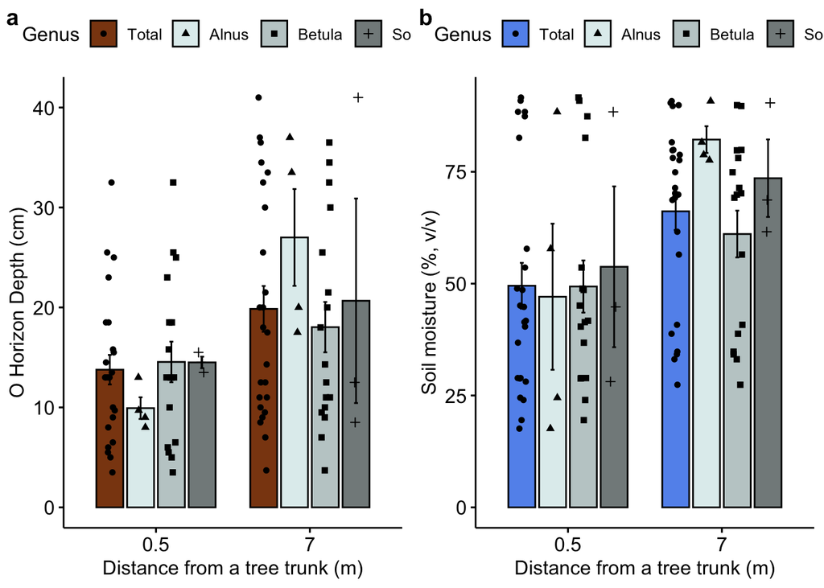

```r
# mutate "total" category in Genus column
datavis <- soil_all_nonpine %>%
  mutate(Genus = "Total")
datavis <- bind_rows(
  soil_all_nonpine, datavis
)

datavis$Genus <- factor(datavis$Genus, levels = c("Total", "Alnus", "Betula", "Sorbus"))

p1 <- ggbarplot(
  datavis, x = "Distance", y = "Depth_cm",
  add = c("mean_se", "jitter"),
  add.params = list(shape = "Genus"),
  fill= "Genus", palette = c(
    "Total" = "#8B4513",
    "Alnus" = "#E0EEEE",
    "Betula" = "#C1CDCD",
    "Sorbus" = "#838B8B"),
  position = position_dodge(0.8)
) +
  labs(x = "Distance from a tree trunk (m)", y = "O Horizon Depth (cm)")

p2 <- ggbarplot(
  datavis, x = "Distance", y = "Moisture_vv",
  add = c("mean_se", "jitter"),
  add.params = list(shape = "Genus"),
  fill= "Genus", palette = c(
    "Total" = "#6495ED",
    "Alnus" = "#E0EEEE",
    "Betula" = "#C1CDCD",
    "Sorbus" = "#838B8B"),
  position = position_dodge(0.8)
) +
  labs(x = "Distance from a tree trunk (m)", y = "Soil moisture (%, v/v)")

ggarrange(p1, p2,
          nrow = 1, ncol = 2,
          labels = c("a", "b"))
```

```r
dev.off()
```

# Linear model: ANOVA for All tree & Genus specific

```r
# All trees
## ANOVA Depth vs. Distance----
depth_lm = lm(Depth_cm ~ Distance, data = soil_all_nonpine)
depth_anov = aov(depth_lm, data = soil_all_nonpine)

table_obj <- tidy(depth_anov)
pander(depth_anov, digits = 3)
```

Analysis of Variance Model

|  | Df | Sum Sq | Mean Sq | F value | Pr(>F) |
| --- | --- | --- | --- | --- | --- |
| **Distance** | 1 | 444 | 444 | 4.98 | 0.0306 |
| **Residuals** | 46 | 4104 | 89.2 | NA | NA |

```r
# p = 0.03, significant difference.

## calculating mean
tapply(soil_all_nonpine$Depth_cm, soil_all_nonpine$Distance, mean, na.rm=TRUE)
```

```
##      0.5        7
## 13.77083 19.85417
```

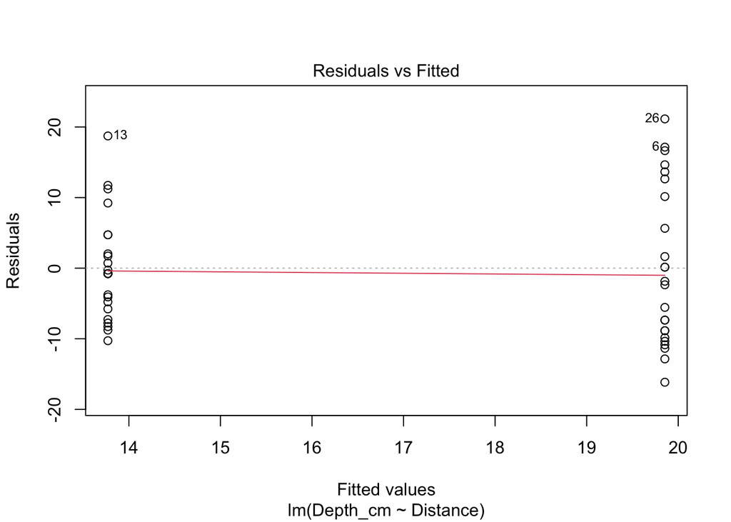

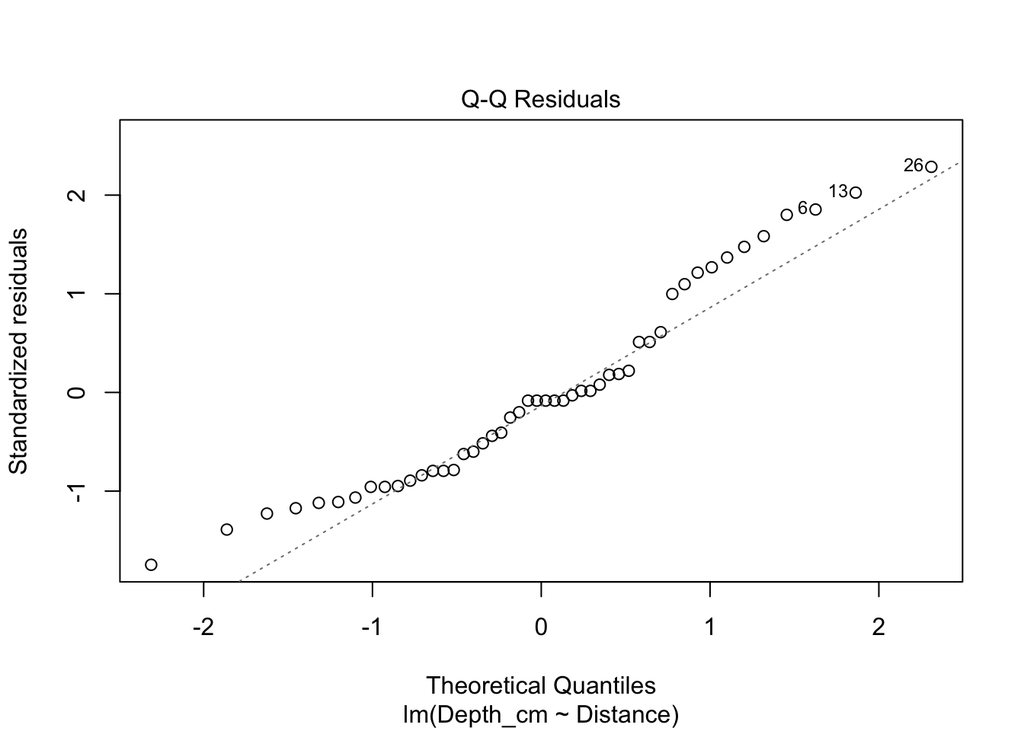

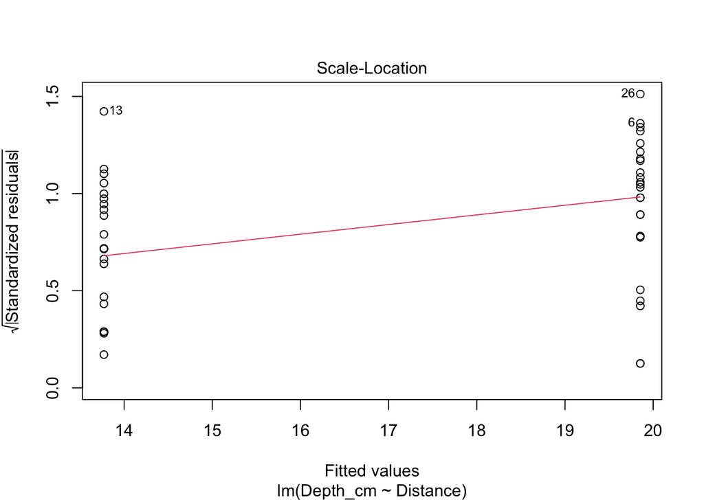

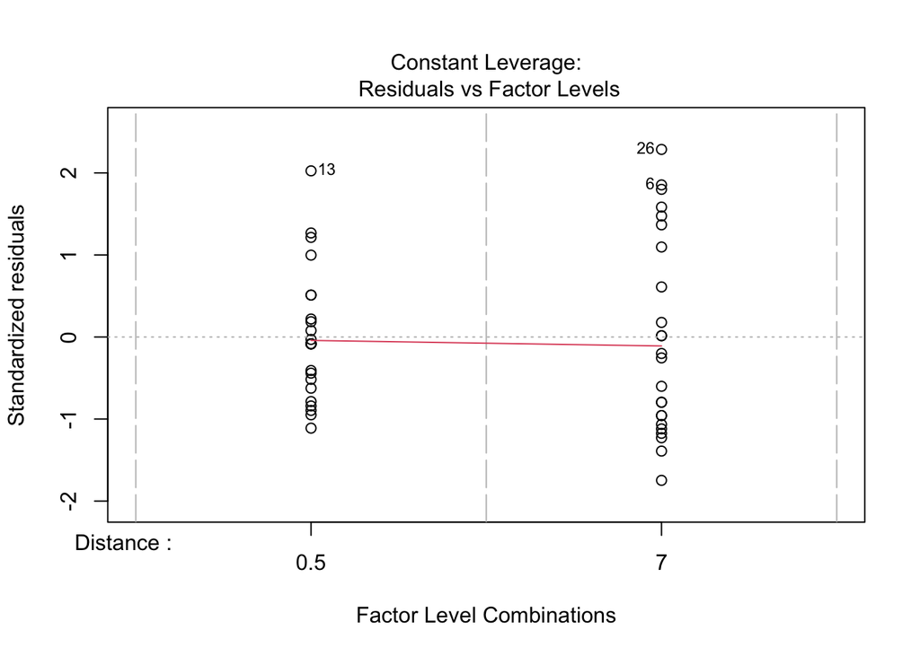

```r
## Anscombe's Quartet
plot(depth_lm)
```

```r
# Residuals vs. fitted: linearity met.
# Q-Q plot generally follows the same line, residuals normally distributed.
# Residuals variances are equal.
# No significant outliers outside the Cook's distance.

## ANOVA Moisture vs. Distance----
moisture_lm <- lm(Moisture_vv ~ Distance, data = soil_all_nonpine)
moisture_anov <- aov(moisture_lm)

table_obj <- tidy(moisture_anov)
pander(moisture_anov, digits = 3)
```

Analysis of Variance Model

|  | Df | Sum Sq | Mean Sq | F value | Pr(>F) |
| --- | --- | --- | --- | --- | --- |
| **Distance** | 1 | 3323 | 3323 | 6.35 | 0.0153 |
| **Residuals** | 46 | 24086 | 524 | NA | NA |

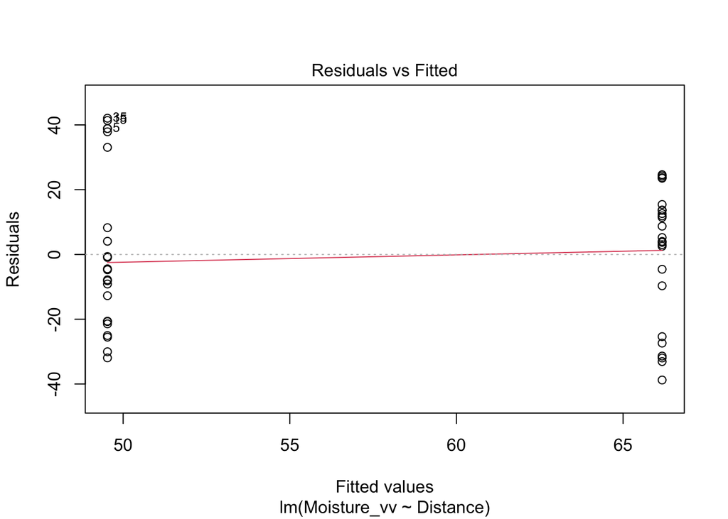

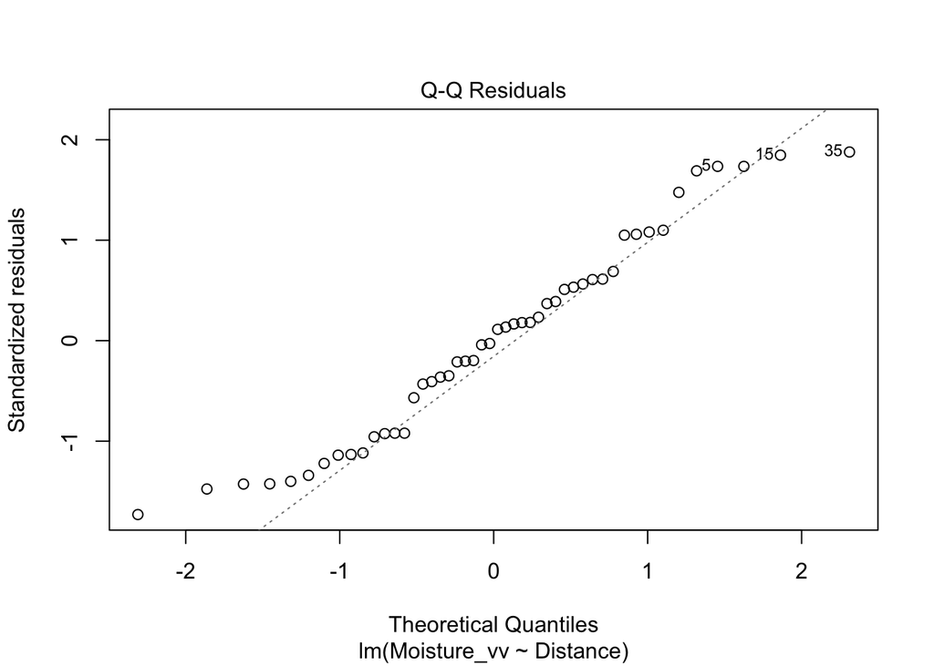

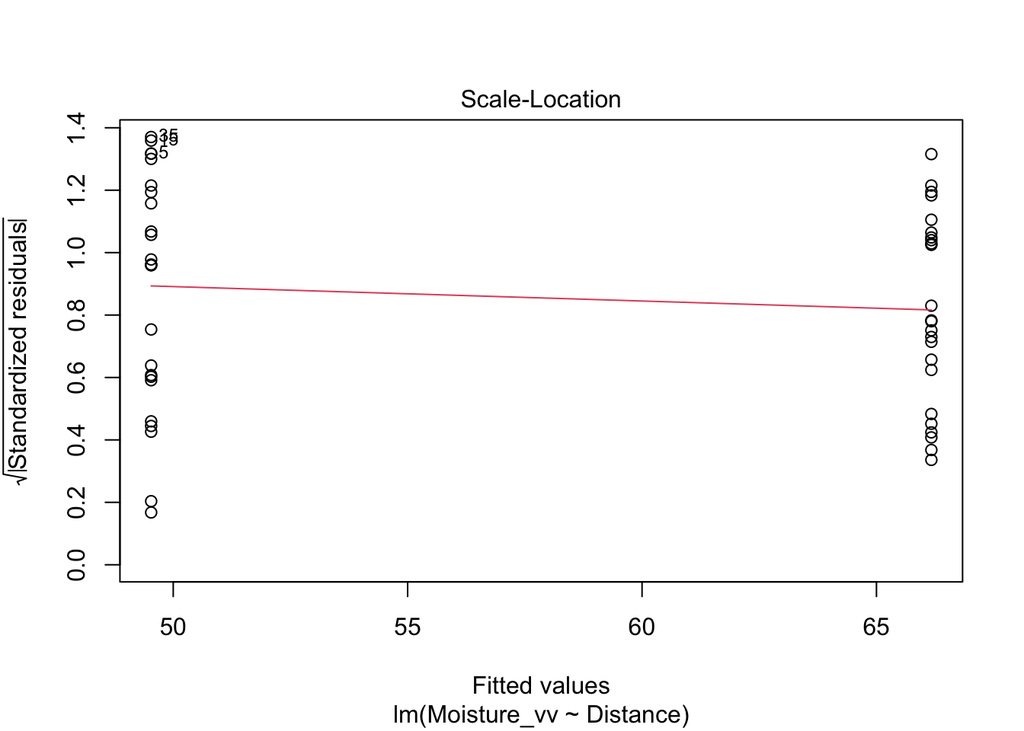

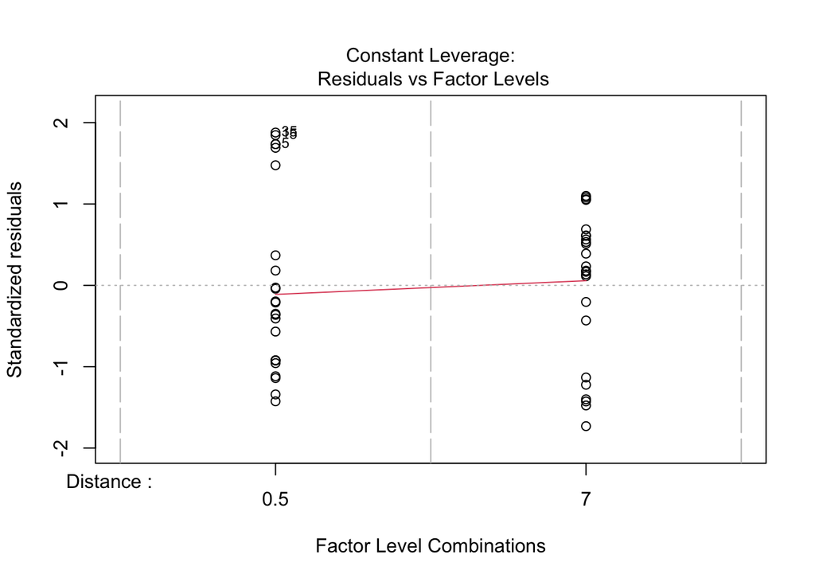

```r
# p = 0.02, significant difference.

## Anscombe's Quartet
plot(moisture_lm)
```

```r
# Linearity met.
# Q-Q plot generally follows the same line.
# Residual variances are generally equal.
# No significant outliers outside the Cook's distance.

# Species Specific
## ANOVA Depth vs. Distance----
## Subset data for One-way ANOVA
Alnus <- subset(soil_all_nonpine,Genus == "Alnus")
Betula <- subset(soil_all_nonpine, Genus == "Betula")
Sorbus <- subset(soil_all_nonpine, Genus == "Sorbus")

## ANOVA
alnus_mod <- aov(Depth_cm ~ Distance, data = Alnus)
table_obj <- tidy(alnus_mod)
pander(alnus_mod, digits = 3)
```

Analysis of Variance Model

|  | Df | Sum Sq | Mean Sq | F value | Pr(>F) |
| --- | --- | --- | --- | --- | --- |
| **Distance** | 1 | 583 | 583 | 11.8 | 0.0138 |
| **Residuals** | 6 | 296 | 49.3 | NA | NA |

```r
# p = 0.01, df = 6. Significant difference.
betula_mod <- aov(Depth_cm ~ Distance, data = Betula)
table_obj <- tidy(betula_mod)
pander(betula_mod, digits = 3)
```

Analysis of Variance Model

|  | Df | Sum Sq | Mean Sq | F value | Pr(>F) |
| --- | --- | --- | --- | --- | --- |
| **Distance** | 1 | 103 | 103 | 1.16 | 0.29 |
| **Residuals** | 32 | 2845 | 88.9 | NA | NA |

```r
# p = 0.29, df = 32, not significant.
sorbus_mod <- aov(Depth_cm ~ Distance, data = Sorbus)
table_obj <- tidy(sorbus_mod)
pander(sorbus_mod, digits = 3)
```

Analysis of Variance Model

|  | Df | Sum Sq | Mean Sq | F value | Pr(>F) |
| --- | --- | --- | --- | --- | --- |
| **Distance** | 1 | 57 | 57 | 0.362 | 0.58 |
| **Residuals** | 4 | 630 | 158 | NA | NA |

```r
# p = 0.58, df = 4, not significant.

## ANOVA Moisture vs. Distance----

## ANOVA
alnus_mod <- aov(Moisture_vv ~ Distance, data = Alnus)
table_obj <- tidy(alnus_mod)
pander(alnus_mod, digits = 3)
```

Analysis of Variance Model

|  | Df | Sum Sq | Mean Sq | F value | Pr(>F) |
| --- | --- | --- | --- | --- | --- |
| **Distance** | 1 | 2468 | 2468 | 4.48 | 0.0788 |
| **Residuals** | 6 | 3308 | 551 | NA | NA |

```r
# p = 0.08, df = 6. not significant.
betula_mod <- aov(Moisture_vv ~ Distance, data = Betula)
table_obj <- tidy(betula_mod)
pander(betula_mod, digits = 3)
```

Analysis of Variance Model

|  | Df | Sum Sq | Mean Sq | F value | Pr(>F) |
| --- | --- | --- | --- | --- | --- |
| **Distance** | 1 | 1171 | 1171 | 2.25 | 0.144 |
| **Residuals** | 32 | 16681 | 521 | NA | NA |

```r
# p = 0.14, df = 32, not significant.
sorbus_mod <- aov(Moisture_vv ~ Distance, data = Sorbus)
table_obj <- tidy(sorbus_mod)
pander(sorbus_mod, digits = 3)
```

Analysis of Variance Model

|  | Df | Sum Sq | Mean Sq | F value | Pr(>F) |
| --- | --- | --- | --- | --- | --- |
| **Distance** | 1 | 588 | 588 | 0.985 | 0.377 |
| **Residuals** | 4 | 2389 | 597 | NA | NA |

```r
# p = 0.38, df = 4, not significant.
```